# Electricity Customer Churn Analysis

#### Hi Team, this is a small example on modelling in R on churn using R-Markdown to generate a HTML output

### About

We take a look at an excerpt of customer data of a large Austrian electricity provider, which has already been slightly simplified. Two Excel-Sheets have been combined, one that contains current customers and the other one contained customers that already changed (churned) to a different provider.

### Implementation

First, we load a decision tree classification library `rpart` and a library to plot decision trees, i.e. `rpart.plot`

```r
library(rpart)
library(rpart.plot)
```

Furthermore, we load the sample data from our data repository online

```r
load(url("http://vault.data-r.com/data/churn.rda"))
```

Now let’s take a look at the data

```r
head(churn)
```

```
##   term gender title age consumption tariff  zip churn
## 1    3      1     0  55         722      3 1160     0
## 2    3      1     0  50        1691      3 1170     0
## 3    3      2     0  42        1311      3 1100     0
## 4    3      2     0  59        5432      3 2491     0
## 5    3      2     1  74        1152      3 1200     0
## 6    3      2     0  56         771      3 1200     0
```

We see that we have 28616 customers with 8 attributes. The attributes have been simplified and the coding scheme is as follows:

| attribute | coding |
| --- | --- |
| gender | 1: female, 2: male |
| tariff | 1: cheap, 2: medium, 3 standard |
| term | 1: less than 2y, 2: 2y-5y, 3: more than 5y |
| title | 0: no title, 1: any title |
| churn | 0: current customer, 1: churned |

age, consumption and zip are not encoded.

Let’s check some attribute distributions:

```r
summary(churn)
```

```
##  term      gender    title          age          consumption
##  1: 2610   1:14002   0:22940   Min.   : 17.00   Min.   :      1
##  2: 3983   2:14614   1: 5676   1st Qu.: 37.00   1st Qu.:   1061
##  3:22023                       Median : 49.00   Median :   1833
##                                Mean   : 50.63   Mean   :   2346
##                                3rd Qu.: 63.00   3rd Qu.:   2938
##                                Max.   :113.00   Max.   :1355695
##                                                 NA's   :2
##      tariff           zip            churn
##  Min.   :1.000   1100   : 2758   Min.   :0.00000
##  1st Qu.:3.000   1220   : 2225   1st Qu.:0.00000
##  Median :3.000   1210   : 2139   Median :0.00000
##  Mean   :2.943   1160   : 1489   Mean   :0.08432
##  3rd Qu.:3.000   1020   : 1470   3rd Qu.:0.00000
##  Max.   :3.000   1030   : 1357   Max.   :1.00000
##                  (Other):17178
```

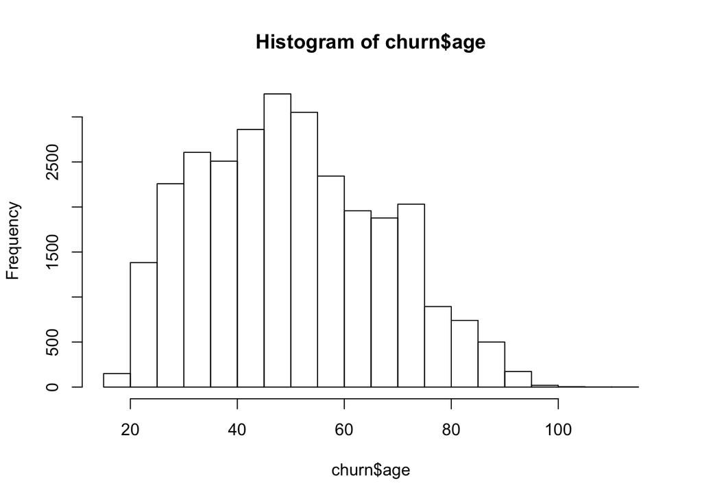

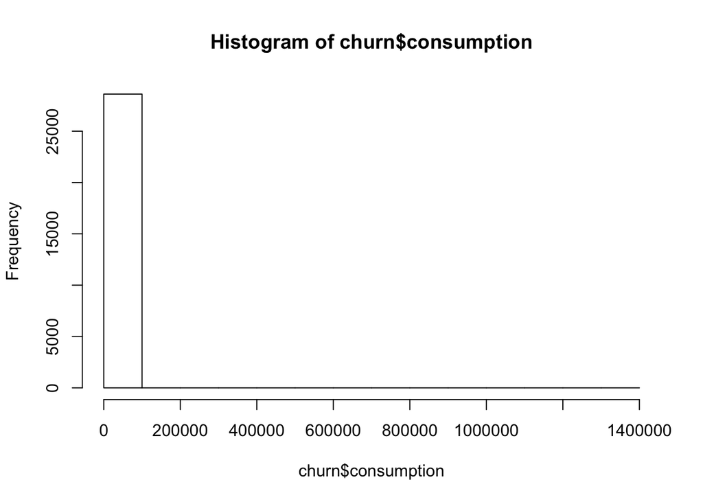

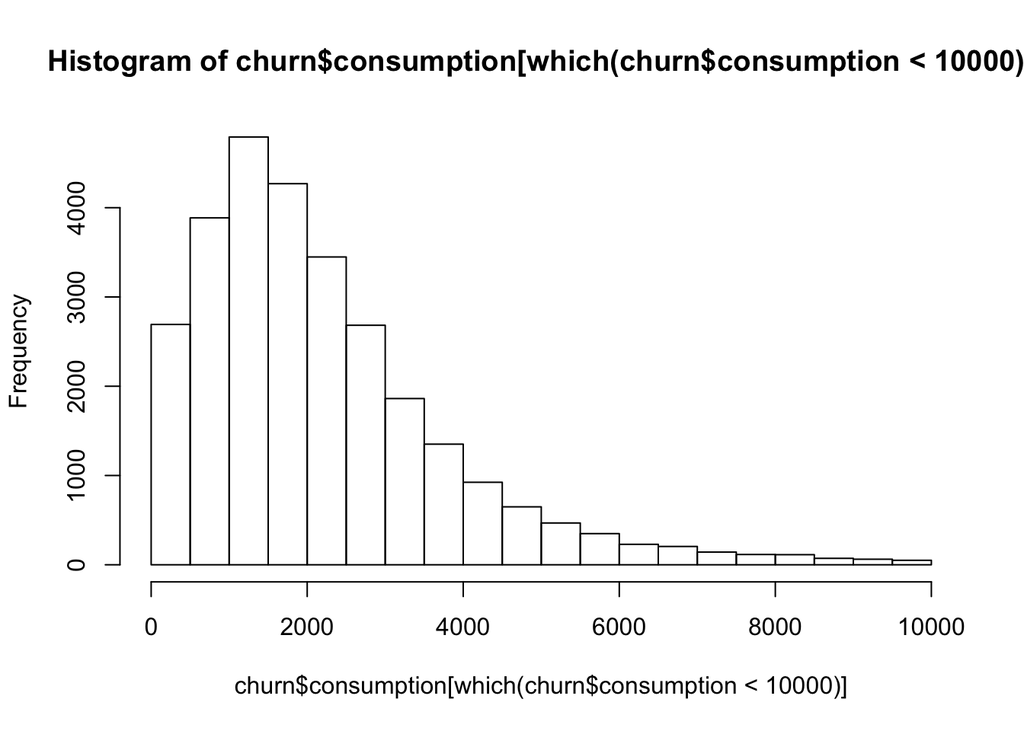

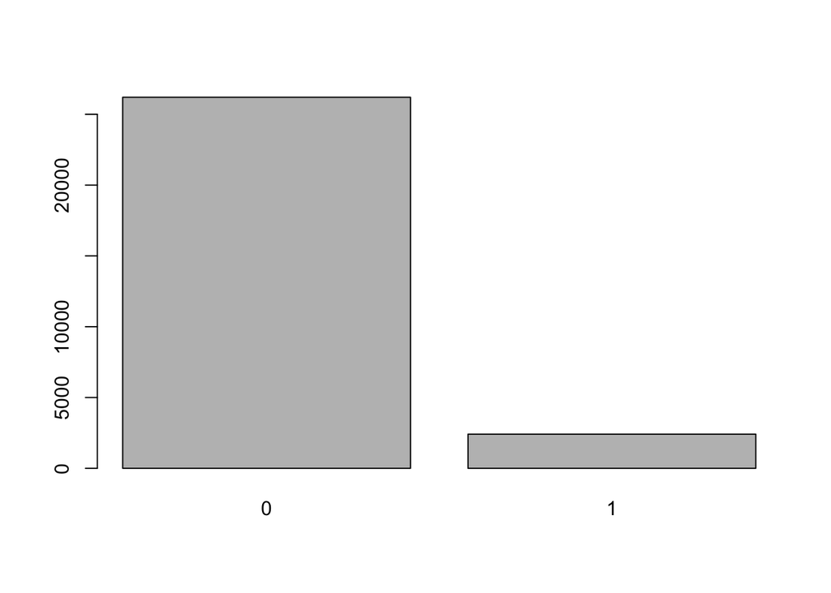

#### Creating a decision tree

Creating a (decision tree) classifier is simple, i.e. a one-liner. The dependent variable is `churn`, which is a qualitative variable, which is why we cannot use standard regression models here, but the syntax is the same:

```r
fit <- rpart(churn ~ term + gender + title + age + consumption + tariff,
             method="class", data=churn)
```

And check the respective decision tree:

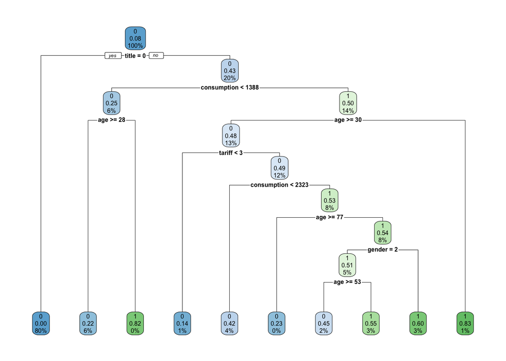